# Study 6 Overview

Cillian McHugh

12th November 2021

# Study 6

Below is an overview analysis for cognitive load Study 6.

# Video Task

[video not shown]

Sample Video Task

# All Scenarios

## Sample size (with breakdown)

```
## [1] 1757
```

```
##
## cog_load  control
##      876      881
```

```
##
##  UK  US
## 886 871
```

```
##
##            Heinz Incest Jennifer Trolley
##   cog_load   212    215      230     219
##   control    221    219      224     217
```

## Testing Effect of Cognitive Load

```
##
##  Pearson's Chi-squared test
##
## data:  table(df3$InCS, df3$condition)
## X-squared = 26.404, df = 2, p-value = 1.847e-06
```

## Frequency Table

Table 1:

*Study 6 – Response to the critical slide depending on cognitive load*

|  | 1 | 2 | 3 | 4 |
| --- | --- | --- | --- | --- |
| It’s wrong and I can provide a valid reason. | 483 | 55% | 587 | 67% |
| It’s wrong but I can’t think of a reason. | 259 | 30% | 178 | 20% |
| There is nothing wrong. | 134 | 15% | 116 | 13% |

## Plot

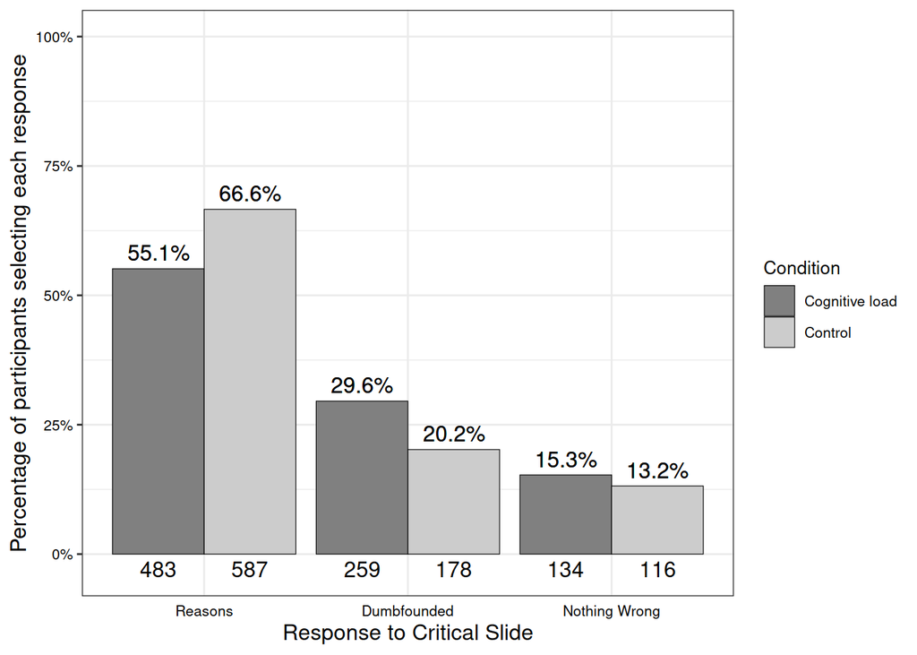

Figure 1: Study 6: Responses to critical slide and for the experimental group and the control group

## Residuals

Table 2:

*Study 6 – Observed counts, expected counts, and standardised residuals for each response to the critical slide depending on cognitive load*

|  |  | Cognitive Load | Control |
| --- | --- | --- | --- |
| Observed count | Reasons | 483 | 587 |
|  | Dumbfounded | 259 | 178 |
|  | Nothing Wrong | 134 | 116 |
| Expected count | Reasons | 533.48 | 536.52 |
|  | Dumbfounded | 217.88 | 219.12 |
|  | Nothing Wrong | 124.64 | 125.36 |
| Standardised residuals | Reasons | -4.94** | 4.94** |
|  | Dumbfounded | 4.54** | -4.54** |
|  | Nothing Wrong | 1.28 | -1.28 |

*Note.* * = sig. at < .05; ** = sig. at < .001

# Each Scenario Individually

## Julie and Mark

### Sample size (with breakdown)

```
## [1] 434
```

```
##
## cog_load  control
##      215      219
```

### Testing Effect of Cognitive Load

```
##
##  Pearson's Chi-squared test
##
## data:  table(df3$InCS, df3$condition)
## X-squared = 0.44045, df = 2, p-value = 0.8023
```

### Frequency Table

Table 3:

*Study 6 – Response to the critical slide depending on cognitive load*

|  | 1 | 2 | 3 | 4 |
| --- | --- | --- | --- | --- |
| It’s wrong and I can provide a valid reason. | 116 | 54% | 125 | 57% |
| It’s wrong but I can’t think of a reason. | 54 | 25% | 52 | 24% |
| There is nothing wrong. | 45 | 21% | 42 | 19% |

### Plot

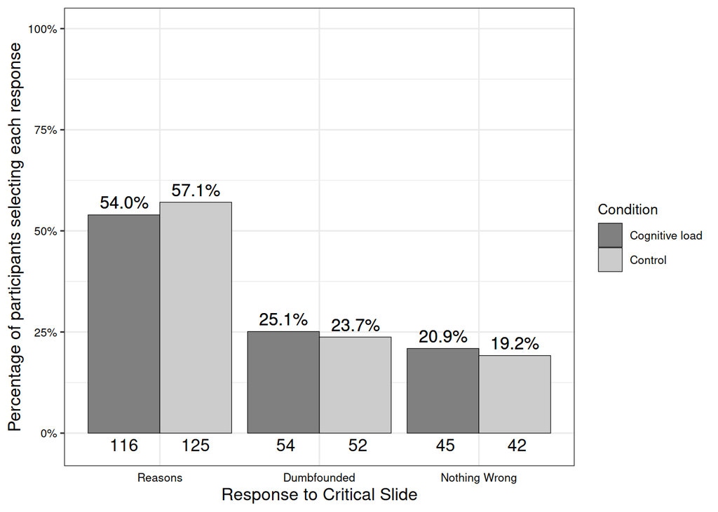

Figure 2: Study 6: Responses to critical slide and for the experimental group and the control group

### Residuals

Table 4:

*Study 6 – Observed counts, expected counts, and standardised residuals for each response to the critical slide depending on cognitive load*

|  |  | Cognitive Load | Control |
| --- | --- | --- | --- |
| Observed count | Reasons | 116.00 | 125.00 |
|  | Dumbfounded | 54.00 | 52.00 |
|  | Nothing Wrong | 45.00 | 42.00 |
| Expected count | Reasons | 119.39 | 121.61 |
|  | Dumbfounded | 52.51 | 53.49 |
|  | Nothing Wrong | 43.10 | 43.90 |
| Standardised residuals | Reasons | -0.65 | 0.65 |
|  | Dumbfounded | 0.33 | -0.33 |
|  | Nothing Wrong | 0.46 | -0.46 |

*Note.* * = sig. at < .05; ** = sig. at < .001

## Jennifer

### Sample size (with breakdown)

```
## [1] 454
```

```
##
## cog_load  control
##      230      224
```

### Testing Effect of Cognitive Load

```
##
##  Pearson's Chi-squared test
##
## data:  table(df3$InCS, df3$condition)
## X-squared = 15.218, df = 2, p-value = 0.0004961
```

### Frequency Table

Table 5:

*Study 6 – Response to the critical slide depending on cognitive load*

|  | 1 | 2 | 3 | 4 |
| --- | --- | --- | --- | --- |
| It’s wrong and I can provide a valid reason. | 151 | 66% | 180 | 80% |
| It’s wrong but I can’t think of a reason. | 69 | 30% | 33 | 15% |
| There is nothing wrong. | 10 | 4% | 11 | 5% |

### Plot

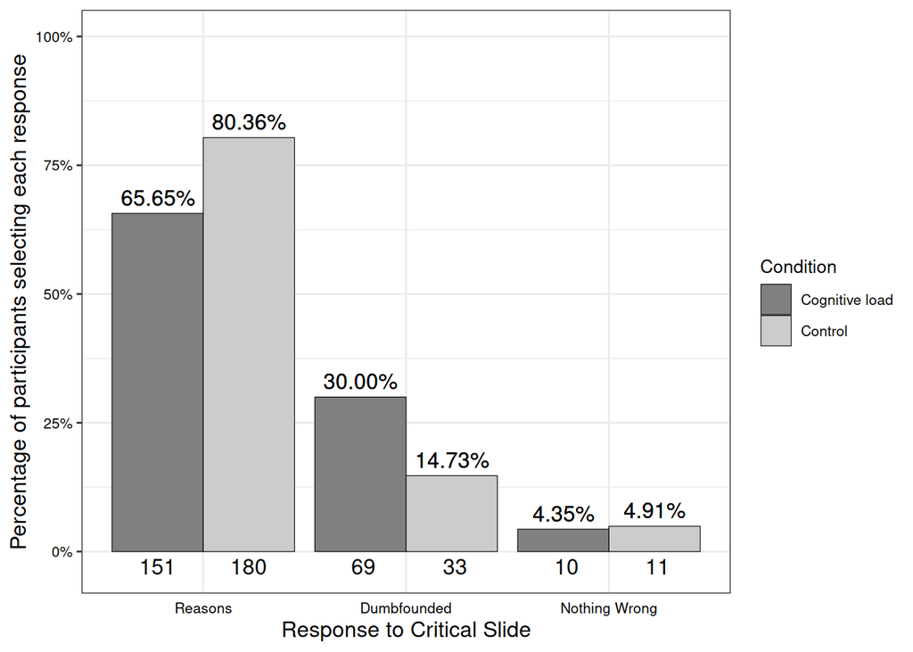

Figure 3: Study 6: Responses to critical slide and for the experimental group and the control group

### Residuals

Table 6:

*Study 6 – Observed counts, expected counts, and standardised residuals for each response to the critical slide depending on cognitive load*

|  |  | Cognitive Load | Control |
| --- | --- | --- | --- |
| Observed count | Reasons | 151 | 180 |
|  | Dumbfounded | 69 | 33 |
|  | Nothing Wrong | 10 | 11 |
| Expected count | Reasons | 167.69 | 163.31 |
|  | Dumbfounded | 51.67 | 50.33 |
|  | Nothing Wrong | 10.64 | 10.36 |
| Standardised residuals | Reasons | -3.52** | 3.52** |
|  | Dumbfounded | 3.9** | -3.9** |
|  | Nothing Wrong | -0.29 | 0.29 |

*Note.* * = sig. at < .05; ** = sig. at < .001

## Trolley

### Sample size (with breakdown)

```
## [1] 436
```

```
##
## cog_load  control
##      219      217
```

### Testing Effect of Cognitive Load

```
##
##  Pearson's Chi-squared test
##
## data:  table(df3$InCS, df3$condition)
## X-squared = 13.559, df = 2, p-value = 0.001137
```

### Frequency Table

Table 7:

*Study 6 – Response to the critical slide depending on cognitive load*

|  | 1 | 2 | 3 | 4 |
| --- | --- | --- | --- | --- |
| It’s wrong and I can provide a valid reason. | 99 | 45% | 136 | 63% |
| It’s wrong but I can’t think of a reason. | 78 | 36% | 55 | 25% |
| There is nothing wrong. | 42 | 19% | 26 | 12% |

### Plot

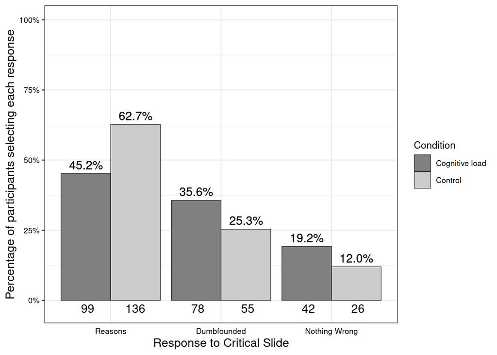

Figure 4: Study 6: Responses to critical slide and for the experimental group and the control group

### Residuals

Table 8:

*Study 6 – Observed counts, expected counts, and standardised residuals for each response to the critical slide depending on cognitive load*

|  |  | Cognitive Load | Control |
| --- | --- | --- | --- |
| Observed count | Reasons | 99 | 136 |
|  | Dumbfounded | 78 | 55 |
|  | Nothing Wrong | 42 | 26 |
| Expected count | Reasons | 118.04 | 116.96 |
|  | Dumbfounded | 66.81 | 66.19 |
|  | Nothing Wrong | 34.16 | 33.84 |
| Standardised residuals | Reasons | -3.66** | 3.66** |
|  | Dumbfounded | 2.33* | -2.33* |
|  | Nothing Wrong | 2.07* | -2.07* |

*Note.* * = sig. at < .05; ** = sig. at < .001

## Heinz

### Sample size (with breakdown)

```
## [1] 433
```

```
##
## cog_load  control
##      212      221
```

### Testing Effect of Cognitive Load

```
##
##  Pearson's Chi-squared test
##
## data:  table(df3$InCS, df3$condition)
## X-squared = 7.1804, df = 2, p-value = 0.02759
```

### Frequency Table

Table 9:

*Study 6 – Response to the critical slide depending on cognitive load*

|  | 1 | 2 | 3 | 4 |
| --- | --- | --- | --- | --- |
| It’s wrong and I can provide a valid reason. | 117 | 55% | 146 | 66% |
| It’s wrong but I can’t think of a reason. | 58 | 27% | 38 | 17% |
| There is nothing wrong. | 37 | 17% | 37 | 17% |

### Plot

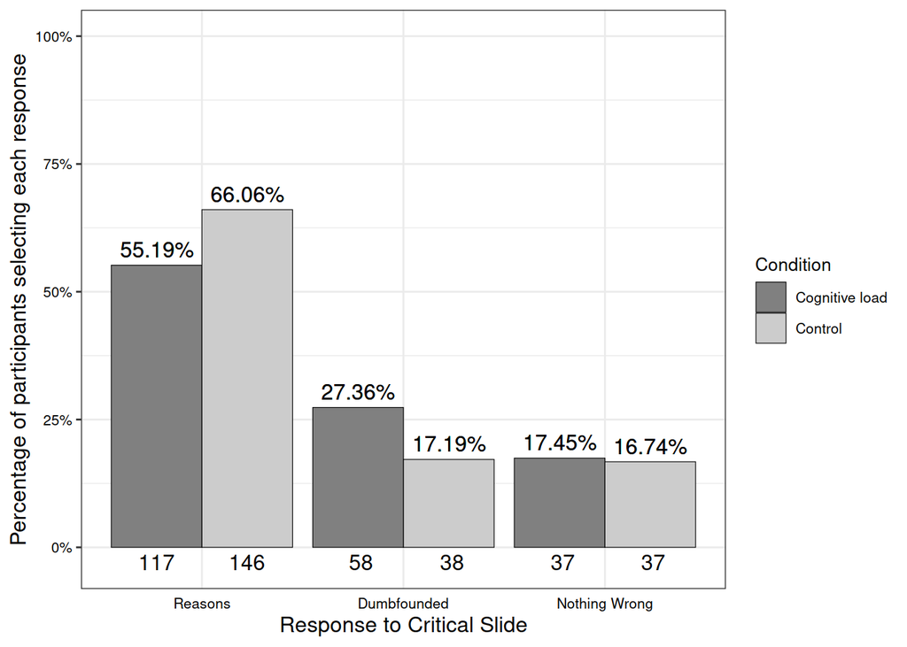

Figure 5: Study 6: Responses to critical slide and for the experimental group and the control group

### Residuals

Table 10:

*Study 6 – Observed counts, expected counts, and standardised residuals for each response to the critical slide depending on cognitive load*

|  |  | Cognitive Load | Control |
| --- | --- | --- | --- |
| Observed count | Reasons | 117 | 146 |
|  | Dumbfounded | 58 | 38 |
|  | Nothing Wrong | 37 | 37 |
| Expected count | Reasons | 128.77 | 134.23 |
|  | Dumbfounded | 47 | 49 |
|  | Nothing Wrong | 36.23 | 37.77 |
| Standardised residuals | Reasons | -2.32* | 2.32* |
|  | Dumbfounded | 2.55* | -2.55* |
|  | Nothing Wrong | 0.2 | -0.2 |

*Note.* * = sig. at < .05; ** = sig. at < .001